# Clase 6. GLM-Binomial: Ejercicio

Oscar Carmona Castro

2025-03-25

## Ejercicio

Con la base de datos **AvesHabitat.csv**, selecciona una especie en particular y ajusta diferentes modelos, al menos 5. Selecciona el más adecuado, realiza la validación y graficar los resultados (**instructor: David Murillo**).

## 1. Cargar paquetes

```r
library(tidyverse)
library(ggeffects)
library(DHARMa)
library(AICcmodavg)
library(multcomp)
library(MuMIn)
```

## 2. Cargar base de datos (AvesHabitat)

```r
Aves = read.csv("data/AvesHabitat.csv",  header= TRUE, dec = ".", stringsAsFactors = TRUE)

View(Aves)
```

Exploración de base de datos

```r
str(Aves)
```

```
## 'data.frame':    119 obs. of  170 variables:
##  $ X           : int  1 2 3 4 5 6 7 8 9 10 ...
##  $ Site        : int  1 1 1 3 3 4 4 5 5 6 ...
##  $ SiteName    : Factor w/ 48 levels "Norma Caf\xe9",..: 7 7 7 1 1 37 37 2 2 23 ...
##  $ VEGID       : Factor w/ 48 levels "1","10P","11P",..: 1 1 1 28 28 39 39 45 45 46 ...
##  $ Type        : Factor w/ 2 levels "C","F": 2 2 2 1 1 2 2 1 1 1 ...
##  $ LAT         : num  15.2 15.2 15.2 15.2 15.2 ...
##  $ LONG        : num  -87.4 -87.4 -87.4 -87.5 -87.5 ...
##  $ ALTITUDE    : num  879 879 879 825 825 868 868 910 910 973 ...
##  $ Aspect      : int  114 114 114 280 280 -1 -1 220 220 220 ...
##  $ Slope       : Factor w/ 4 levels "E","F","M","S": 3 3 3 2 2 4 4 3 3 3 ...
##  $ Description : Factor w/ 48 levels "2013: Young trees and shrubs 2-3m with evidence of previous grazing. Significant understory cover. \n2011:Part "| __truncated__,..: 19 19 19 18 18 34 34 12 12 28 ...
##  $ Understory  : Factor w/ 5 levels "D","G","I","L",..: 5 5 5 3 3 2 2 4 4 3 ...
##  $ Moss        : Factor w/ 2 levels "FALSO","VERDADERO": 1 1 1 1 1 2 2 1 1 1 ...
##  $ H2O         : Factor w/ 2 levels "FALSO","VERDADERO": 1 1 1 2 2 1 1 2 2 2 ...
```

[output cut: 86 more lines]

Eliminar NAs

```r
Aves2 = drop_na(Aves)
```

## 3. Ajuste de modelos

Especie de interés:

- GLABRA

Variables de interés:

- Type
- habitat
- ALTITUDE

```r
Modelos_aves = list (
  "tipo" = glm(GLABRA ~ Type, family = "binomial", data = Aves2),
  "habitat" = glm(GLABRA ~ habitat, family = "binomial", data = Aves2),
  "altitud" = glm(GLABRA ~ ALTITUDE, family = "binomial", data = Aves2),

  "tipo + habitat" = glm(GLABRA ~ Type + habitat, family = "binomial", data = Aves2),
  "habitat + altitud" = glm(GLABRA ~ habitat + ALTITUDE, family = "binomial", data = Aves2),
  "tipo + altitud" = glm(GLABRA ~ Type + ALTITUDE, family = "binomial", data = Aves2)

)
```

## 4. Selección de modelos

```r
aictab(Modelos_aves)
```

```
##
## Model selection based on AICc:
##
##                   K  AICc Delta_AICc AICcWt Cum.Wt     LL
## altitud           2 58.55       0.00   0.22   0.22 -27.12
## tipo              2 58.56       0.01   0.22   0.43 -27.13
## habitat           2 58.56       0.01   0.22   0.65 -27.13
## tipo + habitat    2 58.56       0.01   0.22   0.86 -27.13
## habitat + altitud 3 60.85       2.30   0.07   0.93 -27.12
## tipo + altitud    3 60.85       2.30   0.07   1.00 -27.12
```

Los modelos explican el 100% de la presencia de la especie GLABRA (columna AIC cWt).

Sin embargo seleccionamos los siguientes modelos que explican ≈80% de la presencia de la especie:

- Modelo1 = altitud (22%).
- Modelo2 = tipo (22%)
- Modelo3 = habitat (22%)
- Modelo4 = tipo + habitat (22%)

## 5 Revisión de modelos: variables categóricas

### 5.1 Modelos con variables categóricas (tipo; habitat)

#### 5.1.1 Modelo2 = tipo

```r
summary(Modelos_aves$tipo)
```

```
##
## Call:
## glm(formula = GLABRA ~ Type, family = "binomial", data = Aves2)
##
## Coefficients:
##             Estimate Std. Error z value Pr(>|z|)
## (Intercept) -0.74721    0.40465  -1.847   0.0648 .
## TypeF        0.05407    0.68099   0.079   0.9367
## ---
## Signif. codes:  0 '***' 0.001 '**' 0.01 '*' 0.05 '.' 0.1 ' ' 1
##
## (Dispersion parameter for binomial family taken to be 1)
##
##     Null deviance: 54.266  on 42  degrees of freedom
## Residual deviance: 54.260  on 41  degrees of freedom
## AIC: 58.26
##
## Number of Fisher Scoring iterations: 4
```

Se puede observar que el “Tipo F” tiene mayor probabilidad de explicar la presencia de la especie GLABRA.

INTERCEPTO: TypeC (-0.7472)

TypeF: TypeC + TypeF

Se realiza la transformación a probabilidad (plogis).

```r
plogis(-0.7472) # TypeC
```

```
## [1] 0.3214317
```

Probabilidad de presencia de GLABRA en Tipo C = 32%.

```r
plogis(-0.7472 + 0.0540) # TypeC + TypeF
```

```
## [1] 0.3333216
```

Probabilidad de presencia de GLABRA en Tipo F = 33%

Otra forma, integrando los intervalos de confianza (IC95%)

```r
ggpredict(Modelos_aves$tipo)
```

```
## $Type
## # Predicted probabilities of GLABRA
##
## Type | Predicted |     95% CI
## -----------------------------
## C    |      0.32 | 0.18, 0.51
## F    |      0.33 | 0.15, 0.59
##
##
## attr(,"class")
## [1] "ggalleffects" "list"
## attr(,"model.name")
## [1] "Modelos_aves$tipo"
```

Graficar

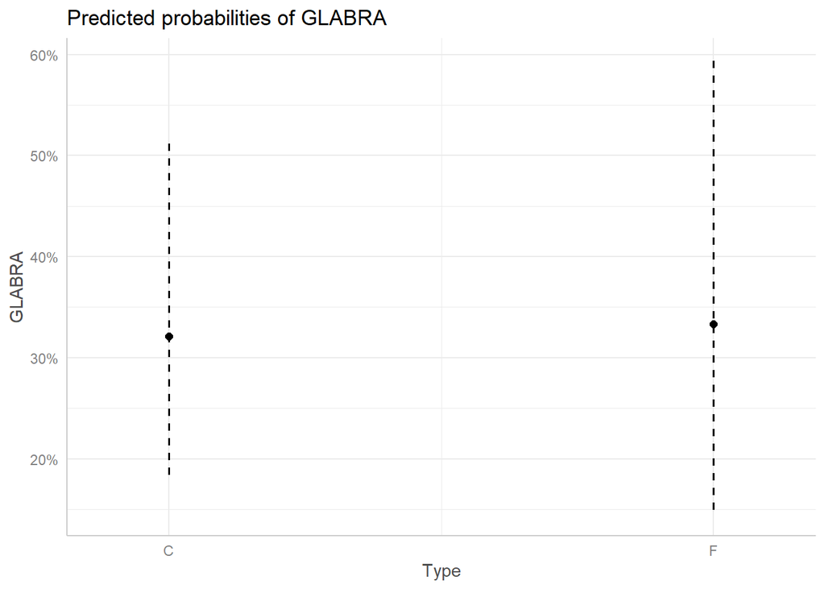

```r
plot(ggpredict(Modelos_aves$tipo))
```

#### 5.1.2 Modelo3 = habitat

```r
summary(Modelos_aves$habitat)
```

```
##
## Call:
## glm(formula = GLABRA ~ habitat, family = "binomial", data = Aves2)
##
## Coefficients:
##             Estimate Std. Error z value Pr(>|z|)
## (Intercept) -0.74721    0.40465  -1.847   0.0648 .
## habitatSF    0.05407    0.68099   0.079   0.9367
## ---
## Signif. codes:  0 '***' 0.001 '**' 0.01 '*' 0.05 '.' 0.1 ' ' 1
##
## (Dispersion parameter for binomial family taken to be 1)
##
##     Null deviance: 54.266  on 42  degrees of freedom
## Residual deviance: 54.260  on 41  degrees of freedom
## AIC: 58.26
##
## Number of Fisher Scoring iterations: 4
```

A pesar de que esta variable contiene tres niveles (AF, PF, SF), solo dos niveles explican la presencia de la especie GLABRA (SF y AF).

Se puede observar que el “habitatSF” tiene mayor probabilidad de explicar la presencia de la especie GLABRA.

INTERCEPTO: habitatAF (-0.7472)

habitatSF: habitatAF + habitatSF

Se realiza la transformación a probabilidad (plogis).

```r
plogis(-0.7472) # habitatAF
```

```
## [1] 0.3214317
```

Probabilidad de presencia de GLABRA en habitatAF = 32%.

```r
plogis(-0.7472 + 0.0540) # habitatAF + habitatSF
```

```
## [1] 0.3333216
```

Otra forma, integrando los intervalos de confianza (IC95%)

```r
ggpredict(Modelos_aves$habitat)
```

```
## $habitat
## # Predicted probabilities of GLABRA
##
## habitat | Predicted |     95% CI
## --------------------------------
## AF      |      0.32 | 0.18, 0.51
## SF      |      0.33 | 0.15, 0.59
##
##
## attr(,"class")
## [1] "ggalleffects" "list"
## attr(,"model.name")
## [1] "Modelos_aves$habitat"
```

Graficar

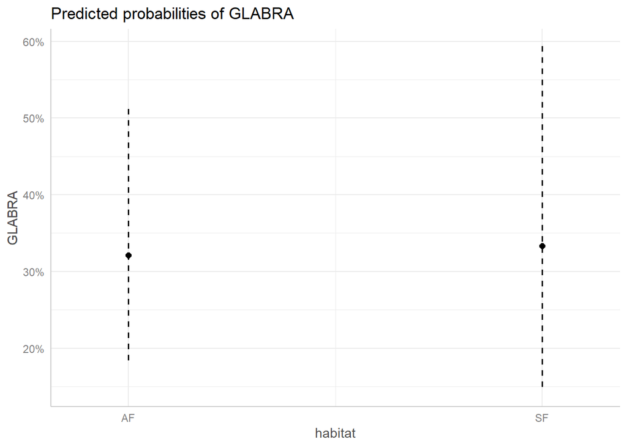

```r
plot(ggpredict(Modelos_aves$habitat))
```

#### 5.1.3 Prueba de contraste

```r
library(multcomp)
```

Modelo2 = tipo

```r
Type_con = glht(Modelos_aves$tipo, mcp("Type" = "Tukey"))
```

```r
summary(Type_con)
```

```
##
##   Simultaneous Tests for General Linear Hypotheses
##
## Multiple Comparisons of Means: Tukey Contrasts
##
##
## Fit: glm(formula = GLABRA ~ Type, family = "binomial", data = Aves2)
##
## Linear Hypotheses:
##            Estimate Std. Error z value Pr(>|z|)
## F - C == 0  0.05407    0.68099   0.079    0.937
## (Adjusted p values reported -- single-step method)
```

No hay diferencias significativas entre el Tipo F y Tipo C, que permitan explicar la presencia de la especie GLABRA.

Modelo3 = habitat

```r
habitat_con = glht(Modelos_aves$habitat, mcp("habitat" = "Tukey"))
```

```r
summary(Type_con)
```

```
##
##   Simultaneous Tests for General Linear Hypotheses
##
## Multiple Comparisons of Means: Tukey Contrasts
##
##
## Fit: glm(formula = GLABRA ~ Type, family = "binomial", data = Aves2)
##
## Linear Hypotheses:
##            Estimate Std. Error z value Pr(>|z|)
## F - C == 0  0.05407    0.68099   0.079    0.937
## (Adjusted p values reported -- single-step method)
```

No hay diferencias significativas entre el Tipo F y Tipo C, que permitan explicar la presencia de la especie GLABRA.

### 5.2 Revisión de modelos: variables numéricas

Ahora evaluaremos el modelo que contiene la variable numérica.

#### 5.2.1 Modelo1 = altitud

```r
summary(Modelos_aves$altitud)
```

```
##
## Call:
## glm(formula = GLABRA ~ ALTITUDE, family = "binomial", data = Aves2)
##
## Coefficients:
##               Estimate Std. Error z value Pr(>|z|)
## (Intercept) -0.5192794  1.6202490  -0.320    0.749
## ALTITUDE    -0.0001879  0.0014293  -0.131    0.895
##
## (Dispersion parameter for binomial family taken to be 1)
##
##     Null deviance: 54.266  on 42  degrees of freedom
## Residual deviance: 54.249  on 41  degrees of freedom
## AIC: 58.249
##
## Number of Fisher Scoring iterations: 4
```

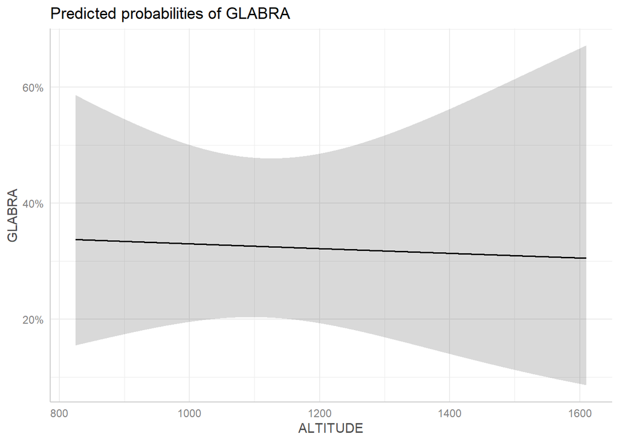

```r
plot(ggpredict(Modelos_aves$altitud, terms = "ALTITUDE[n = 100]"))
```

## 6 Revisión de supuestos

```r
testResiduals(Modelos_aves$tipo)
```

```
## $uniformity
##
##  Exact one-sample Kolmogorov-Smirnov test
##
## data:  simulationOutput$scaledResiduals
## D = 0.11966, p-value = 0.5301
## alternative hypothesis: two-sided
##
##
## $dispersion
##
##  DHARMa nonparametric dispersion test via sd of residuals fitted vs.
##  simulated
##
## data:  simulationOutput
## dispersion = 1.0302, p-value = 1
## alternative hypothesis: two.sided
##
##
## $outliers
##
##  DHARMa bootstrapped outlier test
##
## data:  simulationOutput
## outliers at both margin(s) = 0, observations = 43, p-value = 1
## alternative hypothesis: two.sided
##  percent confidence interval:
##  0 0
## sample estimates:
## outlier frequency (expected: 0 )
##                                0
```

```r
testResiduals(Modelos_aves$habitat)
```

```
## $uniformity
##
##  Exact one-sample Kolmogorov-Smirnov test
##
## data:  simulationOutput$scaledResiduals
## D = 0.11966, p-value = 0.5301
## alternative hypothesis: two-sided
##
##
## $dispersion
##
##  DHARMa nonparametric dispersion test via sd of residuals fitted vs.
##  simulated
##
## data:  simulationOutput
## dispersion = 1.0302, p-value = 1
## alternative hypothesis: two.sided
##
##
## $outliers
##
##  DHARMa bootstrapped outlier test
##
## data:  simulationOutput
## outliers at both margin(s) = 0, observations = 43, p-value = 1
## alternative hypothesis: two.sided
##  percent confidence interval:
##  0 0
## sample estimates:
## outlier frequency (expected: 0 )
##                                0
```

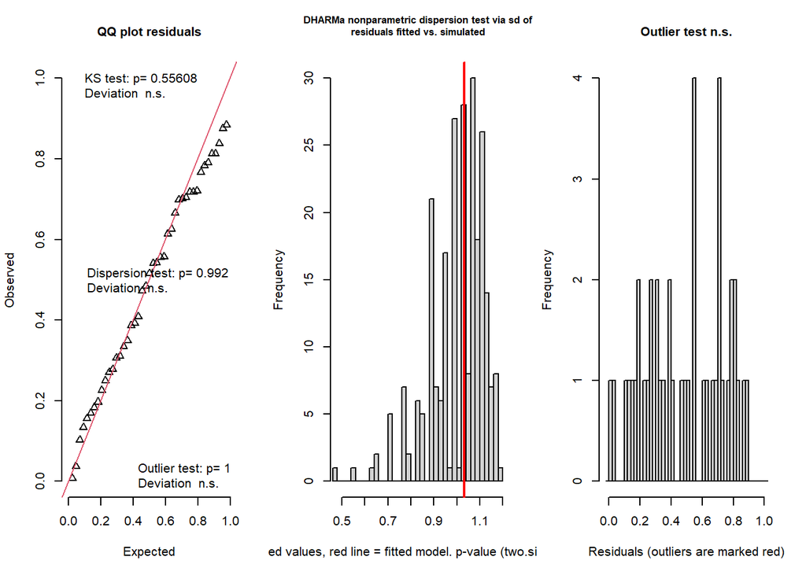

```
## $uniformity
##
##  Exact one-sample Kolmogorov-Smirnov test
##
## data:  simulationOutput$scaledResiduals
## D = 0.11723, p-value = 0.5561
## alternative hypothesis: two-sided
##
##
## $dispersion
##
##  DHARMa nonparametric dispersion test via sd of residuals fitted vs.
##  simulated
##
## data:  simulationOutput
## dispersion = 1.0306, p-value = 0.992
## alternative hypothesis: two.sided
##
##
## $outliers
##
##  DHARMa bootstrapped outlier test
##
## data:  simulationOutput
## outliers at both margin(s) = 0, observations = 43, p-value = 1
## alternative hypothesis: two.sided
##  percent confidence interval:
##  0 0
## sample estimates:
## outlier frequency (expected: 0 )
##                                0
```

```r
testResiduals(Modelos_aves$altitud)
```

```r
testResiduals(Modelos_aves$`tipo + habitat`)
```

```
## $uniformity
##
##  Exact one-sample Kolmogorov-Smirnov test
##
## data:  simulationOutput$scaledResiduals
## D = 0.11966, p-value = 0.5301
## alternative hypothesis: two-sided
##
##
## $dispersion
##
##  DHARMa nonparametric dispersion test via sd of residuals fitted vs.
##  simulated
##
## data:  simulationOutput
## dispersion = 1.0302, p-value = 1
## alternative hypothesis: two.sided
##
##
## $outliers
##
##  DHARMa bootstrapped outlier test
##
## data:  simulationOutput
## outliers at both margin(s) = 0, observations = 43, p-value = 1
## alternative hypothesis: two.sided
##  percent confidence interval:
##  0 0
## sample estimates:
## outlier frequency (expected: 0 )
##                                0
```

```r
tipo_habitat = glm(GLABRA ~ Type + habitat, family = "binomial", data = Aves2)
```

```r
summary(tipo_habitat)
```

```
##
## Call:
## glm(formula = GLABRA ~ Type + habitat, family = "binomial", data = Aves2)
##
## Coefficients: (1 not defined because of singularities)
##             Estimate Std. Error z value Pr(>|z|)
## (Intercept) -0.74721    0.40465  -1.847   0.0648 .
## TypeF        0.05407    0.68099   0.079   0.9367
## habitatSF         NA         NA      NA       NA
## ---
## Signif. codes:  0 '***' 0.001 '**' 0.01 '*' 0.05 '.' 0.1 ' ' 1
##
## (Dispersion parameter for binomial family taken to be 1)
##
##     Null deviance: 54.266  on 42  degrees of freedom
## Residual deviance: 54.260  on 41  degrees of freedom
## AIC: 58.26
##
## Number of Fisher Scoring iterations: 4
```

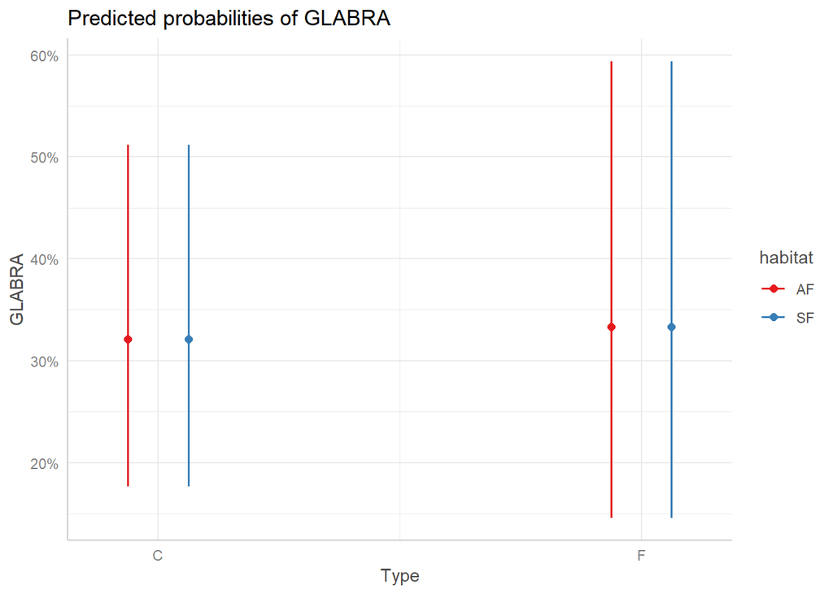

```r
plot(ggpredict(tipo_habitat, terms = c("Type", "habitat")))
```